# Telecom Churn

Xiaoxuan Lu, Cecilia Hu, Yongjun Kim

12/06/2021

```r
library(readr)
library(tidyverse)
library(tibble)
library(gridExtra)
```

# 1 Variable Identification and Initial Transformations

## 1.1 Dataset Overview

```r
churn_data = read.csv('group5.csv')
summary(churn_data)
```

```
##     State           Account.length    Area.code     International.plan
##  Length:3333        Min.   :  1.0   Min.   :408.0   Length:3333
##  Class :character   1st Qu.: 74.0   1st Qu.:408.0   Class :character
##  Mode  :character   Median :101.0   Median :415.0   Mode  :character
##                     Mean   :101.1   Mean   :437.2
##                     3rd Qu.:127.0   3rd Qu.:510.0
##                     Max.   :243.0   Max.   :510.0
##  Voice.mail.plan    Number.email.messages Total.day.minutes Total.day.calls
##  Length:3333        Min.   : 0.000        Min.   :  0.0     Min.   :  0.0
##  Class :character   1st Qu.: 0.000        1st Qu.:143.7     1st Qu.: 87.0
##  Mode  :character   Median : 0.000        Median :179.4     Median :101.0
##                     Mean   : 8.099        Mean   :179.8     Mean   :100.4
##                     3rd Qu.:20.000        3rd Qu.:216.4     3rd Qu.:114.0
##                     Max.   :51.000        Max.   :350.8     Max.   :165.0
##  Total.day.charge Total.eve.minutes Total.eve.calls Total.eve.charge
##  Min.   : 0.00    Min.   :  0.0     Min.   :  0.0   Min.   : 0.00
##  1st Qu.:24.43    1st Qu.:166.6     1st Qu.: 87.0   1st Qu.:14.16
##  Median :30.50    Median :201.4     Median :100.0   Median :17.12
##  Mean   :30.56    Mean   :201.0     Mean   :100.1   Mean   :17.08
##  3rd Qu.:36.79    3rd Qu.:235.3     3rd Qu.:114.0   3rd Qu.:20.00
##  Max.   :59.64    Max.   :363.7     Max.   :170.0   Max.   :30.91
##  Total.night.minutes Total.night.calls Total.night.charge Total.intl.minutes
##  Min.   : 23.2       Min.   : 33.0     Min.   : 1.040     Min.   : 0.00
##  1st Qu.:167.0       1st Qu.: 87.0     1st Qu.: 7.520     1st Qu.: 8.50
##  Median :201.2       Median :100.0     Median : 9.050     Median :10.30
##  Mean   :200.9       Mean   :100.1     Mean   : 9.039     Mean   :10.24
##  3rd Qu.:235.3       3rd Qu.:113.0     3rd Qu.:10.590     3rd Qu.:12.10
##  Max.   :395.0       Max.   :175.0     Max.   :17.770     Max.   :20.00
##  Total.intl.calls Total.intl.charge Customer.service.calls   Churn
##  Min.   : 0.000   Min.   :0.000     Min.   :0.000          Mode :logical
##  1st Qu.: 3.000   1st Qu.:2.300     1st Qu.:1.000          FALSE:2850
##  Median : 4.000   Median :2.780     Median :1.000          TRUE :483
##  Mean   : 4.479   Mean   :2.765     Mean   :1.563
##  3rd Qu.: 6.000   3rd Qu.:3.270     3rd Qu.:2.000
##  Max.   :20.000   Max.   :5.400     Max.   :9.000
```

```r
colnames(churn_data)
```

```
##  [1] "State"                  "Account.length"         "Area.code"
##  [4] "International.plan"     "Voice.mail.plan"        "Number.email.messages"
##  [7] "Total.day.minutes"      "Total.day.calls"        "Total.day.charge"
## [10] "Total.eve.minutes"      "Total.eve.calls"        "Total.eve.charge"
## [13] "Total.night.minutes"    "Total.night.calls"      "Total.night.charge"
## [16] "Total.intl.minutes"     "Total.intl.calls"       "Total.intl.charge"
## [19] "Customer.service.calls" "Churn"
```

# 2 Attributes

## 2.1 Numeric Attributes

```r
colnames(churn_data%>% select_if(is.numeric))
```

```
##  [1] "Account.length"         "Area.code"              "Number.email.messages"
##  [4] "Total.day.minutes"      "Total.day.calls"        "Total.day.charge"
##  [7] "Total.eve.minutes"      "Total.eve.calls"        "Total.eve.charge"
## [10] "Total.night.minutes"    "Total.night.calls"      "Total.night.charge"
## [13] "Total.intl.minutes"     "Total.intl.calls"       "Total.intl.charge"
## [16] "Customer.service.calls"
```

### 2.1.1 Data Quality Issues Observed

- 1. The data is clean, no need to filter out outliers and N/A values.
- 2. Although the range of some attributions are large, for example, the min of Total day minutes is 0 while the 1st quarter is 143, it is acceptable, since the usage of different person is different.

### 2.1.2 Transformations Required

- No Transformations is needed.

### 2.1.3 Attributes For Removal

- No Attribute is going to be removed.

## 2.2 Categorical Attributes

```r
colnames(churn_data%>% select_if(is.character))
```

```
## [1] "State"              "International.plan" "Voice.mail.plan"
```

```r
churn_data[1,]
```

| State | Account.length | Area.code | International.plan | Voice.mail.plan | Number.email.messages | Total.day.minutes | Total.day.calls | Total.day.charge | Total.eve.minutes | Total.eve.calls | Total.eve.charge | Total.night.minutes | Total.night.calls | Total.night.charge | Total.intl.minutes | Total.intl.calls | Total.intl.charge | Customer.service.calls | Churn |
| --- | --- | --- | --- | --- | --- | --- | --- | --- | --- | --- | --- | --- | --- | --- | --- | --- | --- | --- | --- |
| KS | 128 | 415 | No | Yes | 25 | 265.1 | 110 | 45.07 | 197.4 | 99 | 16.78 | 244.7 | 91 | 11.01 | 10 | 3 | 2.7 | 1 | FALSE |

### 2.2.1 Data Quality Issues Observed

- 1. The types of these attributes are all character, need to be transformed to Factor
- 2. “International.plan” and “Voice.mail.plan” have values Yes/No, which need to be changed to TRUE/FALSE in according.
- 3. The data is clean, no need to filter out outliers and N/A values.

### 2.2.2 Transformations Required

- 1. Transform the character type to factor type.
- 2. Transform Yes/No into TRUE/FALSE

```r
# change the yes/no values to TRUE/FALSE
churn_data <- churn_data %>% mutate(International.plan = as.factor(case_when(International.plan=='Yes'~'TRUE',International.plan=='No'~'FALSE')),
                                    Voice.mail.plan = as.factor(case_when(Voice.mail.plan=='Yes'~'TRUE',Voice.mail.plan=='No'~'FALSE')))

# change characters into factors
churn_data <- churn_data %>% mutate(State=as.factor(State),International.plan=as.factor(International.plan),Voice.mail.plan=as.factor(Voice.mail.plan),Churn=as.factor(Churn))
```

```r
# do some check for factors
table(churn_data$Churn)
```

```
##
## FALSE  TRUE
##  2850   483
```

```r
table(churn_data$International.plan)
```

```
##
## FALSE  TRUE
##  3010   323
```

```r
table(churn_data$Voice.mail.plan)
```

```
##
## FALSE  TRUE
##  2411   922
```

```r
length(unique(churn_data$State))
```

```
## [1] 51
```

```r
colnames(churn_data%>%select_if(is.factor))
```

```
## [1] "State"              "International.plan" "Voice.mail.plan"
## [4] "Churn"
```

### 2.2.3 After pre-processing

- “State”: 51 unique values, factor type.
- “International.plan”: Binary values(TRUE/FALSE), factor type
- “Voice.mail.plan”: Binary values(TRUE/FALSE), factor type
- “Churn”: Binary values(TRUE/FALSE), factor type

### 2.2.4 Attributes for Removal

- No Attribute is going to be removed.

# 3 Univariate Analysis

```r
nms = colnames(churn_data %>% select_if(is.numeric))
fcs = colnames(churn_data %>% select_if(is.factor))
```

## 3.1 Numeric Attributes

```r
nms
```

```
##  [1] "Account.length"         "Area.code"              "Number.email.messages"
##  [4] "Total.day.minutes"      "Total.day.calls"        "Total.day.charge"
##  [7] "Total.eve.minutes"      "Total.eve.calls"        "Total.eve.charge"
## [10] "Total.night.minutes"    "Total.night.calls"      "Total.night.charge"
## [13] "Total.intl.minutes"     "Total.intl.calls"       "Total.intl.charge"
## [16] "Customer.service.calls"
```

```r
summarize_numeric<- function(dataset){
  dataset = select_if(dataset,is.numeric)
  summary.table <-data.frame(attributes = names(dataset))
  summary.table = summary.table %>% mutate('Missing Values' = apply(dataset,2,function (x) sum(is.na(x))),'Unique Values' = apply(dataset,2,function (x) length(unique(x))),'Mean'=colMeans(dataset,na.rm=TRUE),'Min'=apply(dataset,2,function (x) min(x,na.rm=TRUE)), 'Max'=apply(dataset,2,function (x) max(x,na.rm=TRUE)),'SD'=apply(dataset,2,function (x) sd(x,na.rm=TRUE)))
  summary.table
}
nm_sum <- summarize_numeric(churn_data)
nm_sum
```

| attributes | Missing Values | Unique Values | Mean | Min | Max | SD |
| --- | --- | --- | --- | --- | --- | --- |
| Account.length | 0 | 212 | 101.064807 | 1.00 | 243.00 | 39.8221059 |
| Area.code | 0 | 3 | 437.182418 | 408.00 | 510.00 | 42.3712905 |
| Number.email.messages | 0 | 46 | 8.099010 | 0.00 | 51.00 | 13.6883654 |
| Total.day.minutes | 0 | 1667 | 179.775097 | 0.00 | 350.80 | 54.4673892 |
| Total.day.calls | 0 | 119 | 100.435644 | 0.00 | 165.00 | 20.0690842 |
| Total.day.charge | 0 | 1667 | 30.562307 | 0.00 | 59.64 | 9.2594346 |
| Total.eve.minutes | 0 | 1611 | 200.980348 | 0.00 | 363.70 | 50.7138444 |
| Total.eve.calls | 0 | 123 | 100.114311 | 0.00 | 170.00 | 19.9226253 |
| Total.eve.charge | 0 | 1440 | 17.083540 | 0.00 | 30.91 | 4.3106676 |
| Total.night.minutes | 0 | 1591 | 200.872037 | 23.20 | 395.00 | 50.5738470 |
| Total.night.calls | 0 | 120 | 100.107711 | 33.00 | 175.00 | 19.5686093 |
| Total.night.charge | 0 | 933 | 9.039325 | 1.04 | 17.77 | 2.2758728 |
| Total.intl.minutes | 0 | 162 | 10.237294 | 0.00 | 20.00 | 2.7918395 |
| Total.intl.calls | 0 | 21 | 4.479448 | 0.00 | 20.00 | 2.4612143 |
| Total.intl.charge | 0 | 162 | 2.764581 | 0.00 | 5.40 | 0.7537726 |
| Customer.service.calls | 0 | 10 | 1.562856 | 0.00 | 9.00 | 1.3154910 |

Account infomation: Account.length, Area.code Message: Number.email.messages Minutes:Total.day.minutes;Total.eve.minutes;Total.night.minutes;Total.intl.minutes Call: Total.day.calls;Total.eve.calls;Total.night.calls;Total.intl.calls Charges:Total.day.charge;Total.eve.charge;Total.night.charge;Total.intl.charge Service: Customer.service.calls

#### 3.1.1.1 Account infomation

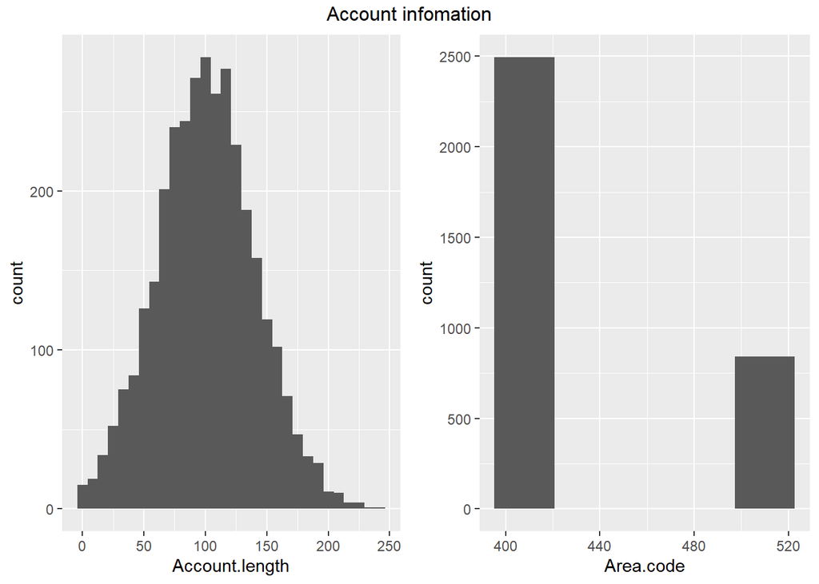

```r
grid.arrange(ggplot(churn_data) + geom_histogram(aes(x=Account.length),bins=30),
             ggplot(churn_data) + geom_histogram(aes(x=Area.code),bins=5),
             ncol=2,top='Account infomation')
```

#### 3.1.1.2 Message

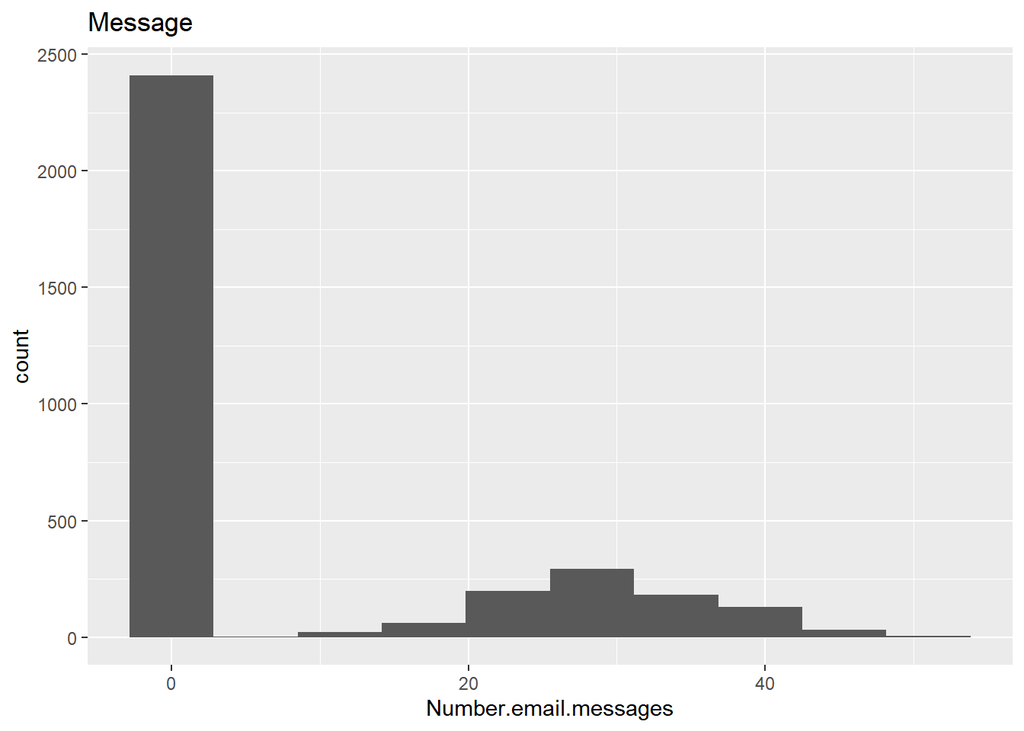

```r
ggplot(churn_data) + geom_histogram(aes(x=Number.email.messages),bins=10)+ ggtitle("Message")
```

#### 3.1.1.3 Minutes

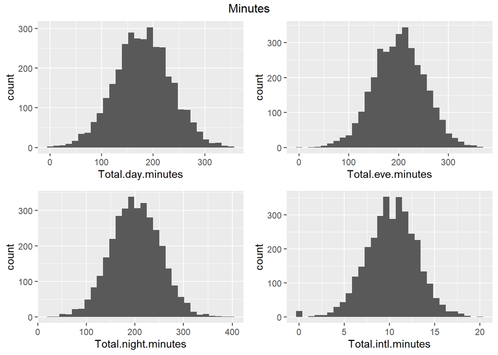

```r
grid.arrange(ggplot(churn_data) + geom_histogram(aes(x=Total.day.minutes),bins=30),
             ggplot(churn_data) + geom_histogram(aes(x=Total.eve.minutes),bins=30),
             ggplot(churn_data) + geom_histogram(aes(x=Total.night.minutes),bins=30),
             ggplot(churn_data) + geom_histogram(aes(x=Total.intl.minutes),bins=30),
             top='Minutes',ncol=2)
```

#### 3.1.1.4 Calls

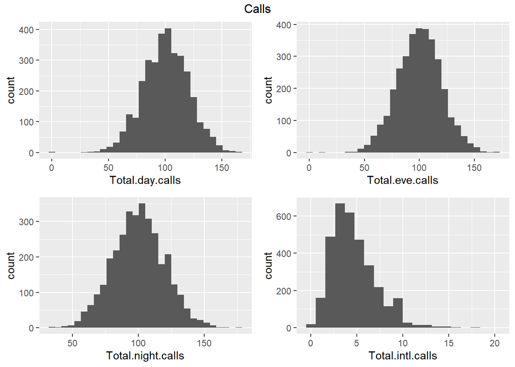

```r
grid.arrange(ggplot(churn_data) + geom_histogram(aes(x=Total.day.calls),bins=30),
             ggplot(churn_data) + geom_histogram(aes(x=Total.eve.calls),bins=30),
             ggplot(churn_data) + geom_histogram(aes(x=Total.night.calls),bins=30),
             ggplot(churn_data) + geom_histogram(aes(x=Total.intl.calls),bins=20),
             top='Calls',ncol=2)
```

#### 3.1.1.5 Charge

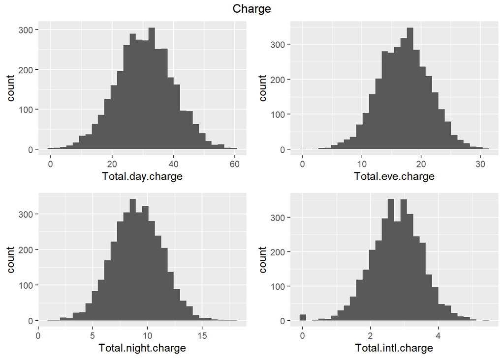

```r
grid.arrange(ggplot(churn_data) + geom_histogram(aes(x=Total.day.charge),bins=30),
             ggplot(churn_data) + geom_histogram(aes(x=Total.eve.charge),bins=30),
             ggplot(churn_data) + geom_histogram(aes(x=Total.night.charge),bins=30),
             ggplot(churn_data) + geom_histogram(aes(x=Total.intl.charge),bins=30),
             top='Charge',ncol=2)
```

#### 3.1.1.6 Service

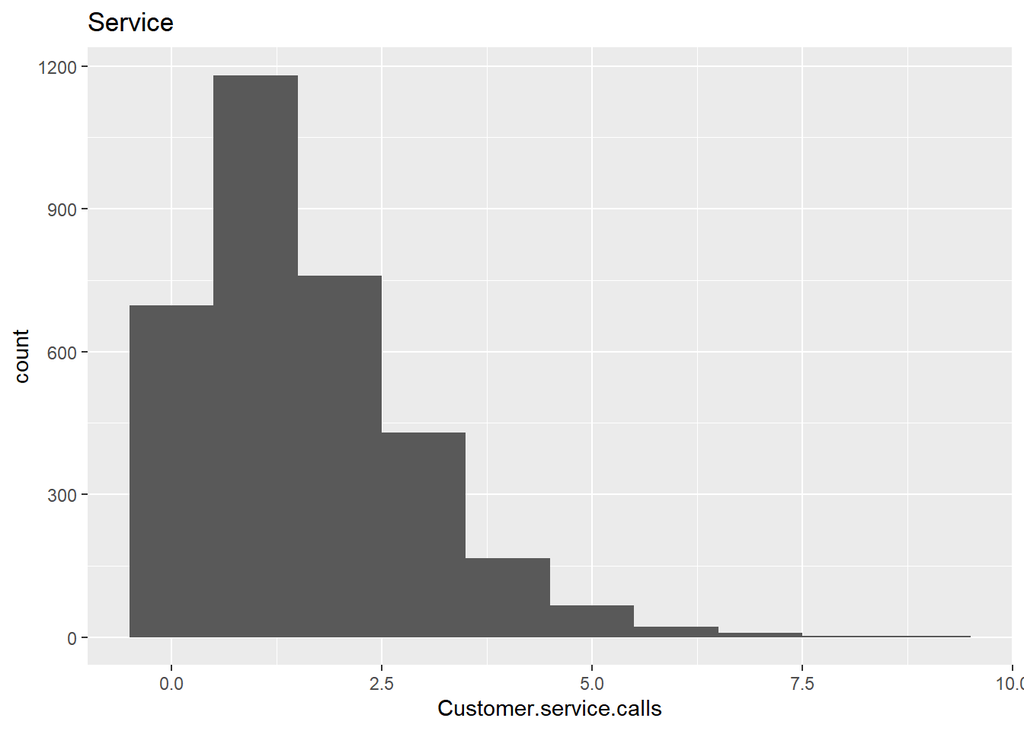

```r
ggplot(churn_data) + geom_histogram(aes(x=Customer.service.calls),bins=10)+ ggtitle("Service")
```

## 3.2 Character Attributes

```r
fcs
```

```
## [1] "State"              "International.plan" "Voice.mail.plan"
## [4] "Churn"
```

```r
churn_data %>% select(fcs) %>% summary()
```

```
## Note: Using an external vector in selections is ambiguous.
## i Use `all_of(fcs)` instead of `fcs` to silence this message.
## i See <https://tidyselect.r-lib.org/reference/faq-external-vector.html>.
```

```
##      State      International.plan Voice.mail.plan   Churn
##  WV     : 106   FALSE:3010         FALSE:2411      FALSE:2850
##  MN     :  84   TRUE : 323         TRUE : 922      TRUE : 483
##  NY     :  83
##  AL     :  80
##  OH     :  78
##  OR     :  78
##  (Other):2824
```

### 3.2.1 Group them into 2 groups

1. Usage info: State; International.plan; Voice.mail.plan
2. Churn info: Churn

## 3.3 Usage info

```r
summarize_factor<- function(dataset){
  dataset = select_if(dataset,is.factor)
  summary.table <-data.frame(attributes = names(dataset))
  summary.table = summary.table %>% mutate('Missing Values' = apply(dataset,2,function (x) sum(is.na(x))),'Unique Values' = apply(dataset,2,function (x) length(unique(x))))
  summary.table
}
fc_sum <- summarize_factor(churn_data)
```

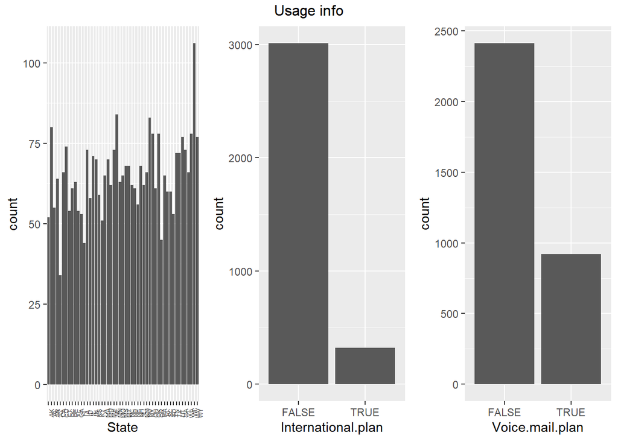

```r
grid.arrange(ggplot(churn_data) + geom_bar(aes(x=State))+theme(axis.text.x = element_text(angle = 90, size = 5)),
             ggplot(churn_data) + geom_bar(aes(x=International.plan)),
             ggplot(churn_data) + geom_bar(aes(x=Voice.mail.plan)),
             top='Usage info',ncol=3)
```

#### 3.3.0.1 Churn info

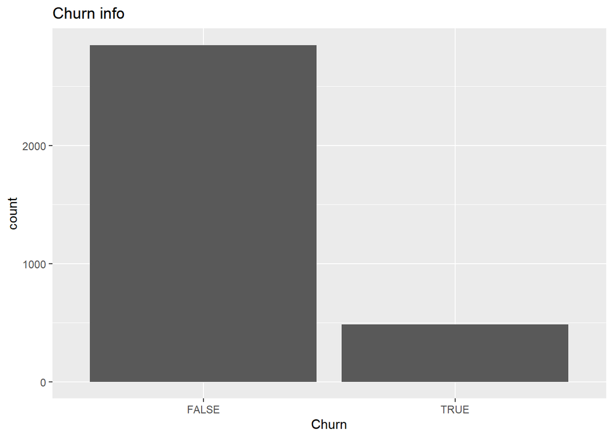

```r
ggplot(churn_data) + geom_bar(aes(x=Churn))+ ggtitle("Churn info")
```

# 4 Bivariate Analysis

## 4.1 Measure/Measure

Account infomation: Account.length, Area.code Message: Number.email.messages Minutes:Total.day.minutes;Total.eve.minutes;Total.night.minutes;Total.intl.minutes Call: Total.day.calls;Total.eve.calls;Total.night.calls;Total.intl.calls Charges:Total.day.charge;Total.eve.charge;Total.night.charge;Total.intl.charge Service: Customer.service.calls

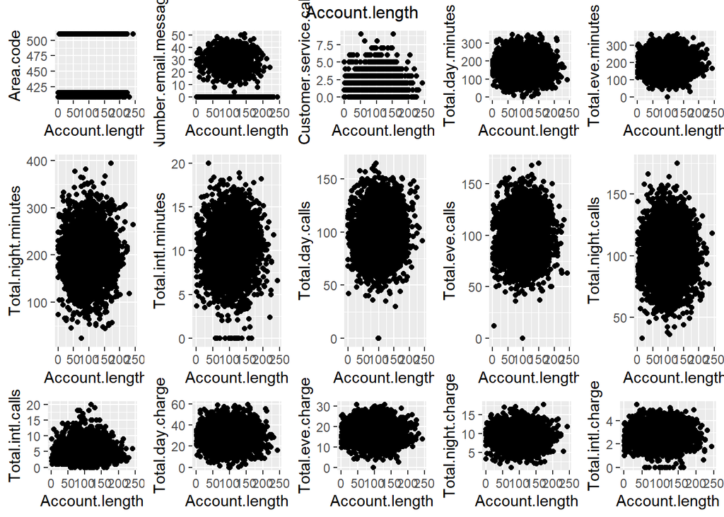

```r
grid.arrange(ggplot(churn_data) + geom_point(aes(x=Account.length, y = Area.code)),
             ggplot(churn_data)+ geom_point(aes(x=Account.length, y = Number.email.messages)),
             ggplot(churn_data)+ geom_point(aes(x=Account.length, y = Customer.service.calls)),
             ggplot(churn_data)+ geom_point(aes(x=Account.length, y = Total.day.minutes)),
             ggplot(churn_data)+ geom_point(aes(x=Account.length, y = Total.eve.minutes)),
             ggplot(churn_data)+ geom_point(aes(x=Account.length, y = Total.night.minutes)),
             ggplot(churn_data)+ geom_point(aes(x=Account.length, y = Total.intl.minutes)),
             ggplot(churn_data)+ geom_point(aes(x=Account.length, y = Total.day.calls)),
             ggplot(churn_data)+ geom_point(aes(x=Account.length, y = Total.eve.calls)),
             ggplot(churn_data)+ geom_point(aes(x=Account.length, y = Total.night.calls)),
             ggplot(churn_data)+ geom_point(aes(x=Account.length, y = Total.intl.calls)),
             ggplot(churn_data)+ geom_point(aes(x=Account.length, y = Total.day.charge)),
             ggplot(churn_data)+ geom_point(aes(x=Account.length, y = Total.eve.charge)),
             ggplot(churn_data)+ geom_point(aes(x=Account.length, y = Total.night.charge)),
             ggplot(churn_data)+ geom_point(aes(x=Account.length, y = Total.intl.charge)),
             top='Account.length',nrow=3,
             heights = c(2, 4, 2))
```

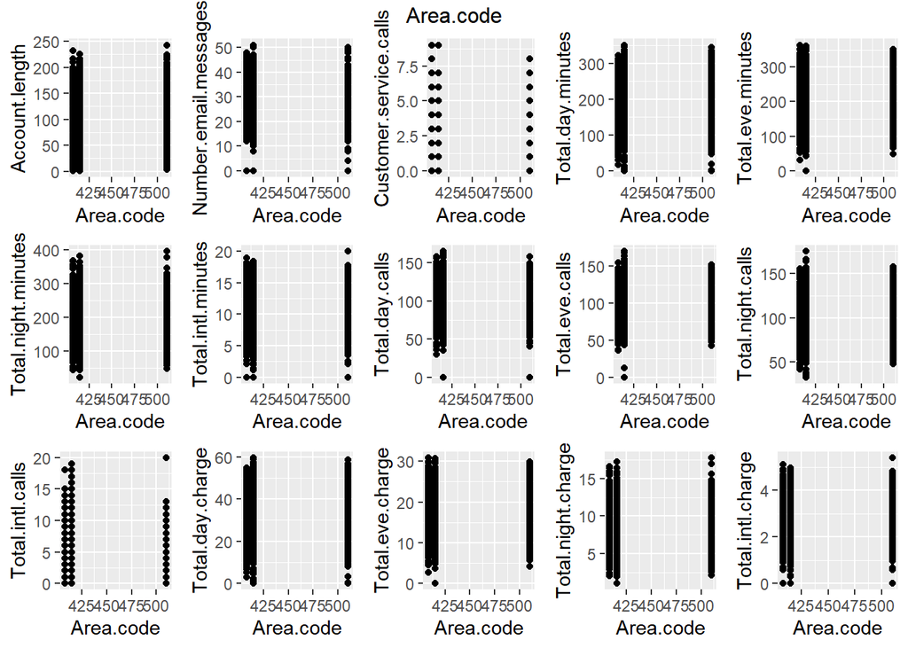

```r
grid.arrange(ggplot(churn_data) + geom_point(aes(x=Area.code, y = Account.length)),
             ggplot(churn_data)+ geom_point(aes(x=Area.code, y = Number.email.messages)),
             ggplot(churn_data)+ geom_point(aes(x=Area.code, y = Customer.service.calls)),
             ggplot(churn_data)+ geom_point(aes(x=Area.code, y = Total.day.minutes)),
             ggplot(churn_data)+ geom_point(aes(x=Area.code, y = Total.eve.minutes)),
             ggplot(churn_data)+ geom_point(aes(x=Area.code, y = Total.night.minutes)),
             ggplot(churn_data)+ geom_point(aes(x=Area.code, y = Total.intl.minutes)),
             ggplot(churn_data)+ geom_point(aes(x=Area.code, y = Total.day.calls)),
             ggplot(churn_data)+ geom_point(aes(x=Area.code, y = Total.eve.calls)),
             ggplot(churn_data)+ geom_point(aes(x=Area.code, y = Total.night.calls)),
             ggplot(churn_data)+ geom_point(aes(x=Area.code, y = Total.intl.calls)),
             ggplot(churn_data)+ geom_point(aes(x=Area.code, y = Total.day.charge)),
             ggplot(churn_data)+ geom_point(aes(x=Area.code, y = Total.eve.charge)),
             ggplot(churn_data)+ geom_point(aes(x=Area.code, y = Total.night.charge)),
             ggplot(churn_data)+ geom_point(aes(x=Area.code, y = Total.intl.charge)),
             top='Area.code',nrow=3,
             heights = c(2, 2, 2))
```

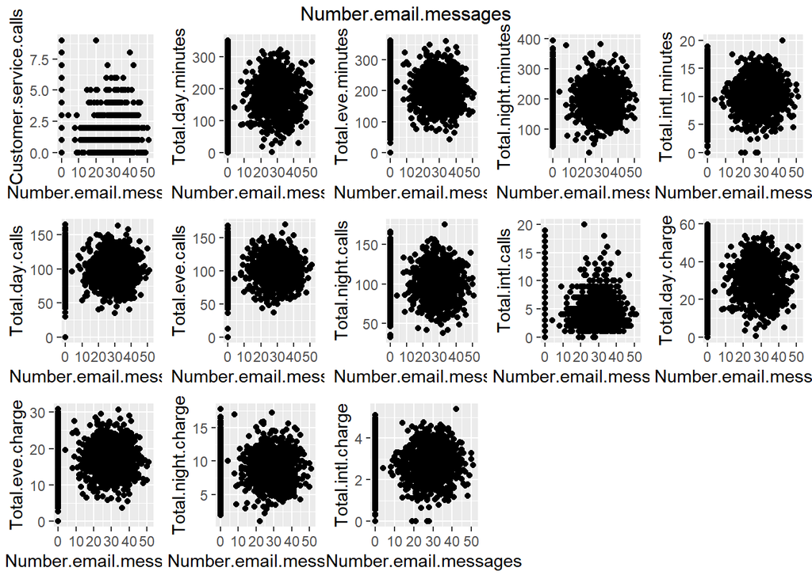

```r
grid.arrange(ggplot(churn_data)+ geom_point(aes(x=Number.email.messages, y = Customer.service.calls)),
             ggplot(churn_data)+ geom_point(aes(x=Number.email.messages, y = Total.day.minutes)),
             ggplot(churn_data)+ geom_point(aes(x=Number.email.messages, y = Total.eve.minutes)),
             ggplot(churn_data)+ geom_point(aes(x=Number.email.messages, y = Total.night.minutes)),
             ggplot(churn_data)+ geom_point(aes(x=Number.email.messages, y = Total.intl.minutes)),
             ggplot(churn_data)+ geom_point(aes(x=Number.email.messages, y = Total.day.calls)),
             ggplot(churn_data)+ geom_point(aes(x=Number.email.messages, y = Total.eve.calls)),
             ggplot(churn_data)+ geom_point(aes(x=Number.email.messages, y = Total.night.calls)),
             ggplot(churn_data)+ geom_point(aes(x=Number.email.messages, y = Total.intl.calls)),
             ggplot(churn_data)+ geom_point(aes(x=Number.email.messages, y = Total.day.charge)),
             ggplot(churn_data)+ geom_point(aes(x=Number.email.messages, y = Total.eve.charge)),
             ggplot(churn_data)+ geom_point(aes(x=Number.email.messages, y = Total.night.charge)),
             ggplot(churn_data)+ geom_point(aes(x=Number.email.messages, y = Total.intl.charge)),
             top='Number.email.messages',nrow=3,
             heights = c(2, 2, 2))
```

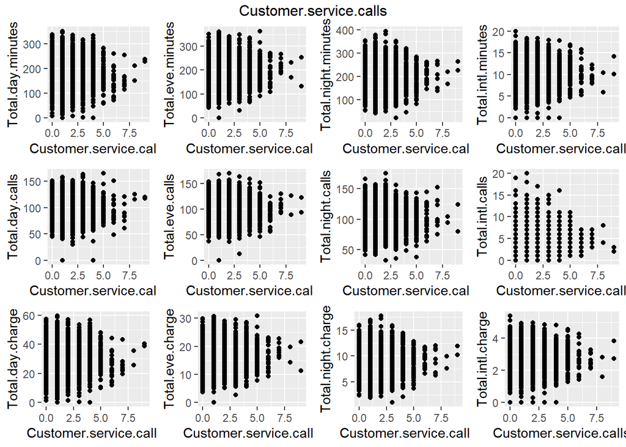

```r
grid.arrange(ggplot(churn_data)+ geom_point(aes(x=Customer.service.calls, y = Total.day.minutes)),
             ggplot(churn_data)+ geom_point(aes(x=Customer.service.calls, y = Total.eve.minutes)),
             ggplot(churn_data)+ geom_point(aes(x=Customer.service.calls, y = Total.night.minutes)),
             ggplot(churn_data)+ geom_point(aes(x=Customer.service.calls, y = Total.intl.minutes)),
             ggplot(churn_data)+ geom_point(aes(x=Customer.service.calls, y = Total.day.calls)),
             ggplot(churn_data)+ geom_point(aes(x=Customer.service.calls, y = Total.eve.calls)),
             ggplot(churn_data)+ geom_point(aes(x=Customer.service.calls, y = Total.night.calls)),
             ggplot(churn_data)+ geom_point(aes(x=Customer.service.calls, y = Total.intl.calls)),
             ggplot(churn_data)+ geom_point(aes(x=Customer.service.calls, y = Total.day.charge)),
             ggplot(churn_data)+ geom_point(aes(x=Customer.service.calls, y = Total.eve.charge)),
             ggplot(churn_data)+ geom_point(aes(x=Customer.service.calls, y = Total.night.charge)),
             ggplot(churn_data)+ geom_point(aes(x=Customer.service.calls, y = Total.intl.charge)),
             top='Customer.service.calls',nrow=3,
             heights = c(2, 2, 2))
```

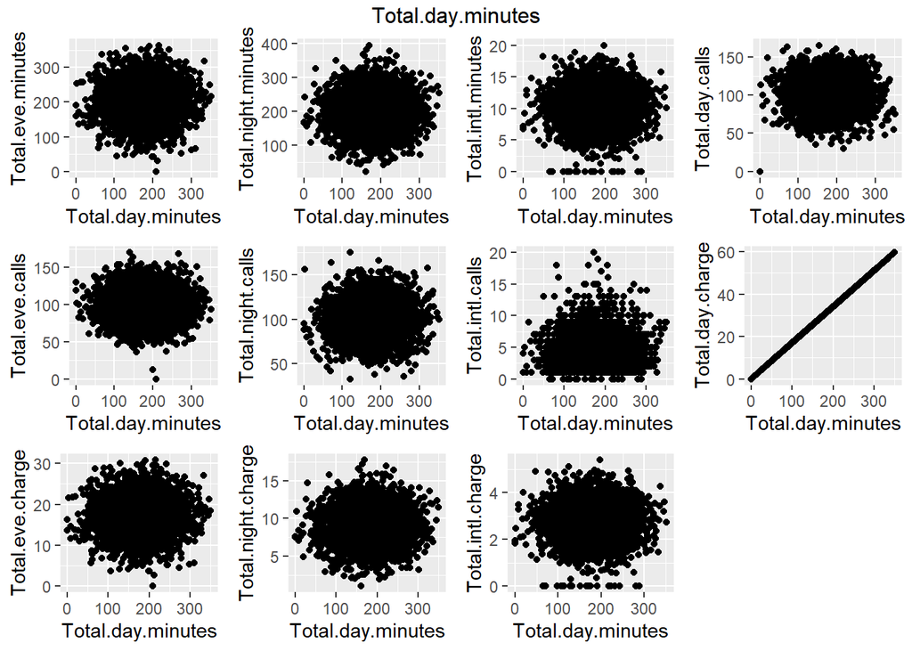

```r
grid.arrange(ggplot(churn_data)+ geom_point(aes(x=Total.day.minutes, y = Total.eve.minutes)),
             ggplot(churn_data)+ geom_point(aes(x=Total.day.minutes, y = Total.night.minutes)),
             ggplot(churn_data)+ geom_point(aes(x=Total.day.minutes, y = Total.intl.minutes)),
             ggplot(churn_data)+ geom_point(aes(x=Total.day.minutes, y = Total.day.calls)),
             ggplot(churn_data)+ geom_point(aes(x=Total.day.minutes, y = Total.eve.calls)),
             ggplot(churn_data)+ geom_point(aes(x=Total.day.minutes, y = Total.night.calls)),
             ggplot(churn_data)+ geom_point(aes(x=Total.day.minutes, y = Total.intl.calls)),
             ggplot(churn_data)+ geom_point(aes(x=Total.day.minutes, y = Total.day.charge)),
             ggplot(churn_data)+ geom_point(aes(x=Total.day.minutes, y = Total.eve.charge)),
             ggplot(churn_data)+ geom_point(aes(x=Total.day.minutes, y = Total.night.charge)),
             ggplot(churn_data)+ geom_point(aes(x=Total.day.minutes, y = Total.intl.charge)),
             top='Total.day.minutes',nrow=3,
             heights = c(2, 2, 2))
```

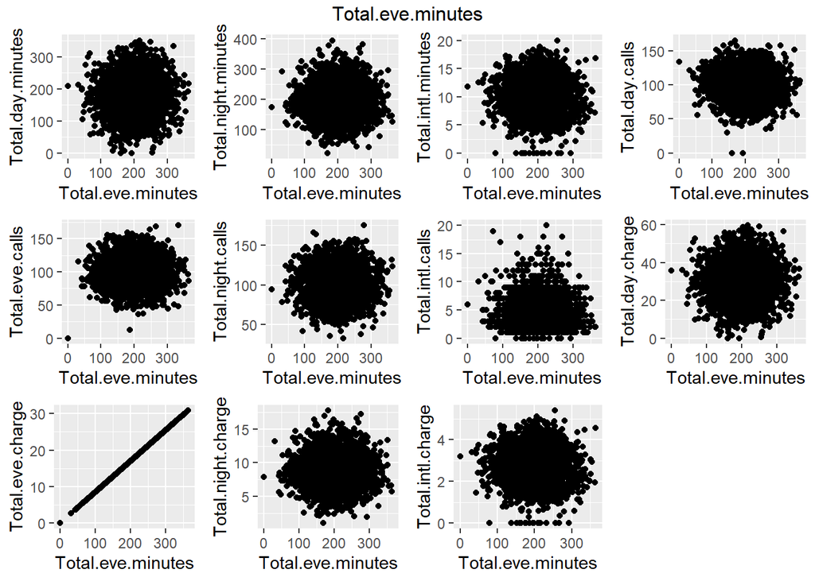

```r
grid.arrange(ggplot(churn_data)+ geom_point(aes(x=Total.eve.minutes, y = Total.day.minutes)),
             ggplot(churn_data)+ geom_point(aes(x=Total.eve.minutes, y = Total.night.minutes)),
             ggplot(churn_data)+ geom_point(aes(x=Total.eve.minutes, y = Total.intl.minutes)),
             ggplot(churn_data)+ geom_point(aes(x=Total.eve.minutes, y = Total.day.calls)),
             ggplot(churn_data)+ geom_point(aes(x=Total.eve.minutes, y = Total.eve.calls)),
             ggplot(churn_data)+ geom_point(aes(x=Total.eve.minutes, y = Total.night.calls)),
             ggplot(churn_data)+ geom_point(aes(x=Total.eve.minutes, y = Total.intl.calls)),
             ggplot(churn_data)+ geom_point(aes(x=Total.eve.minutes, y = Total.day.charge)),
             ggplot(churn_data)+ geom_point(aes(x=Total.eve.minutes, y = Total.eve.charge)),
             ggplot(churn_data)+ geom_point(aes(x=Total.eve.minutes, y = Total.night.charge)),
             ggplot(churn_data)+ geom_point(aes(x=Total.eve.minutes, y = Total.intl.charge)),
             top='Total.eve.minutes',nrow=3,
             heights = c(2, 2, 2))
```

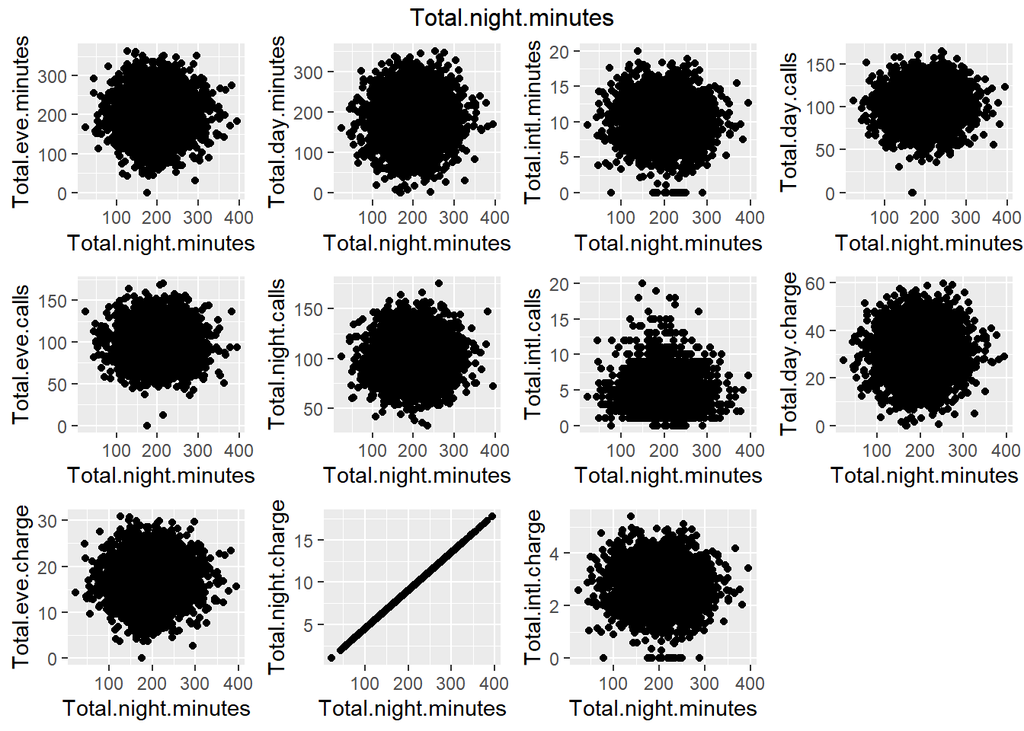

```r
grid.arrange(ggplot(churn_data)+ geom_point(aes(x=Total.night.minutes, y = Total.eve.minutes)),
             ggplot(churn_data)+ geom_point(aes(x=Total.night.minutes, y = Total.day.minutes)),
             ggplot(churn_data)+ geom_point(aes(x=Total.night.minutes, y = Total.intl.minutes)),
             ggplot(churn_data)+ geom_point(aes(x=Total.night.minutes, y = Total.day.calls)),
             ggplot(churn_data)+ geom_point(aes(x=Total.night.minutes, y = Total.eve.calls)),
             ggplot(churn_data)+ geom_point(aes(x=Total.night.minutes, y = Total.night.calls)),
             ggplot(churn_data)+ geom_point(aes(x=Total.night.minutes, y = Total.intl.calls)),
             ggplot(churn_data)+ geom_point(aes(x=Total.night.minutes, y = Total.day.charge)),
             ggplot(churn_data)+ geom_point(aes(x=Total.night.minutes, y = Total.eve.charge)),
             ggplot(churn_data)+ geom_point(aes(x=Total.night.minutes, y = Total.night.charge)),
             ggplot(churn_data)+ geom_point(aes(x=Total.night.minutes, y = Total.intl.charge)),
             top='Total.night.minutes',nrow=3,
             heights = c(2, 2, 2))
```

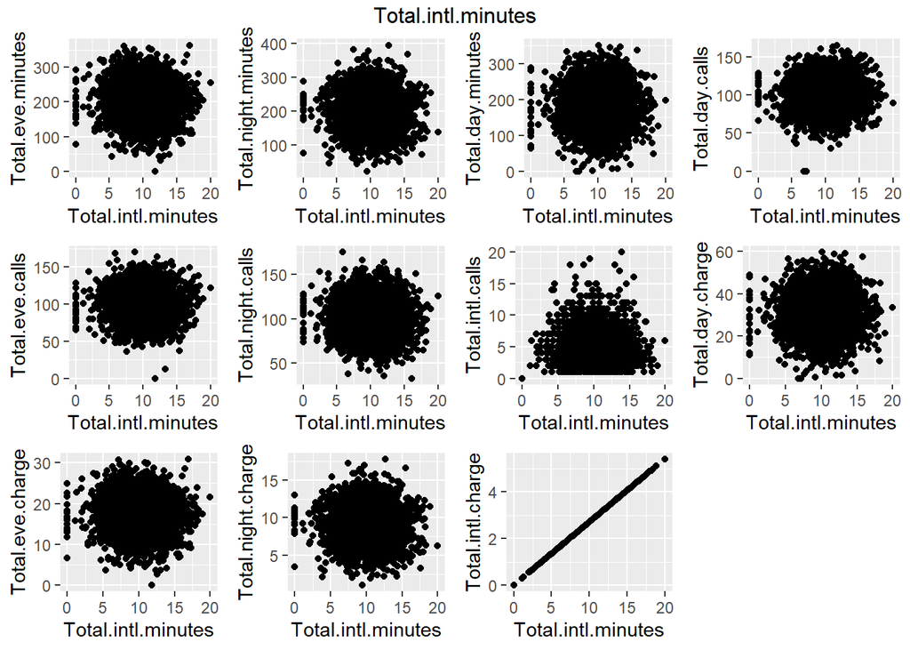

```r
grid.arrange(ggplot(churn_data)+ geom_point(aes(x=Total.intl.minutes, y = Total.eve.minutes)),
             ggplot(churn_data)+ geom_point(aes(x=Total.intl.minutes, y = Total.night.minutes)),
             ggplot(churn_data)+ geom_point(aes(x=Total.intl.minutes, y = Total.day.minutes)),
             ggplot(churn_data)+ geom_point(aes(x=Total.intl.minutes, y = Total.day.calls)),
             ggplot(churn_data)+ geom_point(aes(x=Total.intl.minutes, y = Total.eve.calls)),
             ggplot(churn_data)+ geom_point(aes(x=Total.intl.minutes, y = Total.night.calls)),
             ggplot(churn_data)+ geom_point(aes(x=Total.intl.minutes, y = Total.intl.calls)),
             ggplot(churn_data)+ geom_point(aes(x=Total.intl.minutes, y = Total.day.charge)),
             ggplot(churn_data)+ geom_point(aes(x=Total.intl.minutes, y = Total.eve.charge)),
             ggplot(churn_data)+ geom_point(aes(x=Total.intl.minutes, y = Total.night.charge)),
             ggplot(churn_data)+ geom_point(aes(x=Total.intl.minutes, y = Total.intl.charge)),
             top='Total.intl.minutes',nrow=3,
             heights = c(2, 2, 2))
```

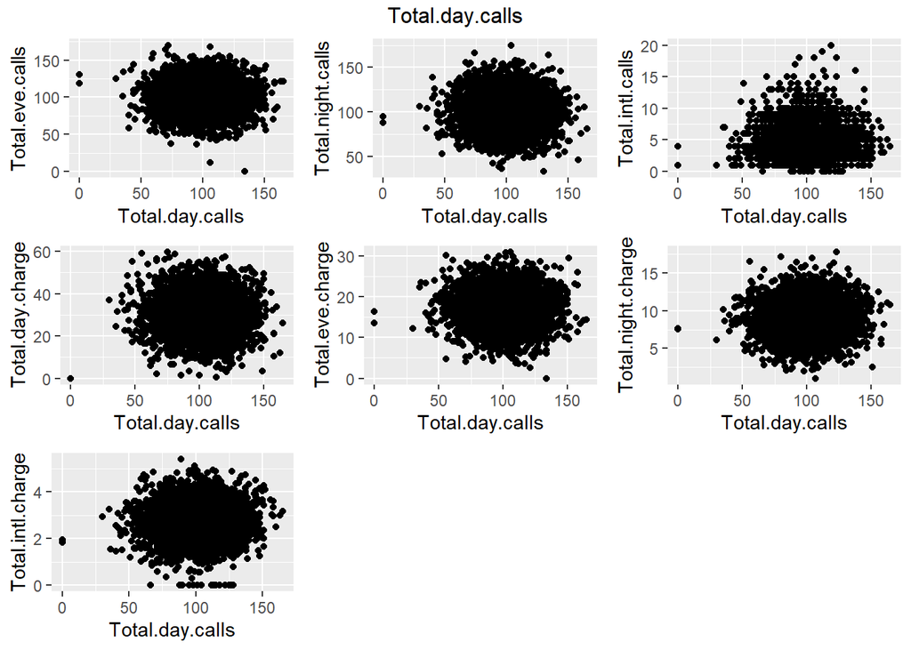

```r
grid.arrange(ggplot(churn_data)+ geom_point(aes(x=Total.day.calls, y = Total.eve.calls)),
             ggplot(churn_data)+ geom_point(aes(x=Total.day.calls, y = Total.night.calls)),
             ggplot(churn_data)+ geom_point(aes(x=Total.day.calls, y = Total.intl.calls)),
             ggplot(churn_data)+ geom_point(aes(x=Total.day.calls, y = Total.day.charge)),
             ggplot(churn_data)+ geom_point(aes(x=Total.day.calls, y = Total.eve.charge)),
             ggplot(churn_data)+ geom_point(aes(x=Total.day.calls, y = Total.night.charge)),
             ggplot(churn_data)+ geom_point(aes(x=Total.day.calls, y = Total.intl.charge)),
             top='Total.day.calls',nrow=3,
             heights = c(2, 2, 2))
```

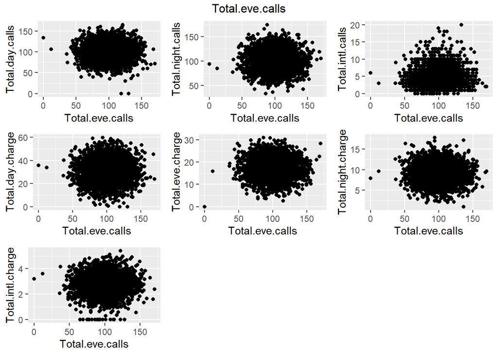

```r
grid.arrange(ggplot(churn_data)+ geom_point(aes(x=Total.eve.calls, y = Total.day.calls)),
             ggplot(churn_data)+ geom_point(aes(x=Total.eve.calls, y = Total.night.calls)),
             ggplot(churn_data)+ geom_point(aes(x=Total.eve.calls, y = Total.intl.calls)),
             ggplot(churn_data)+ geom_point(aes(x=Total.eve.calls, y = Total.day.charge)),
             ggplot(churn_data)+ geom_point(aes(x=Total.eve.calls, y = Total.eve.charge)),
             ggplot(churn_data)+ geom_point(aes(x=Total.eve.calls, y = Total.night.charge)),
             ggplot(churn_data)+ geom_point(aes(x=Total.eve.calls, y = Total.intl.charge)),
             top='Total.eve.calls',nrow=3,
             heights = c(2, 2, 2))
```

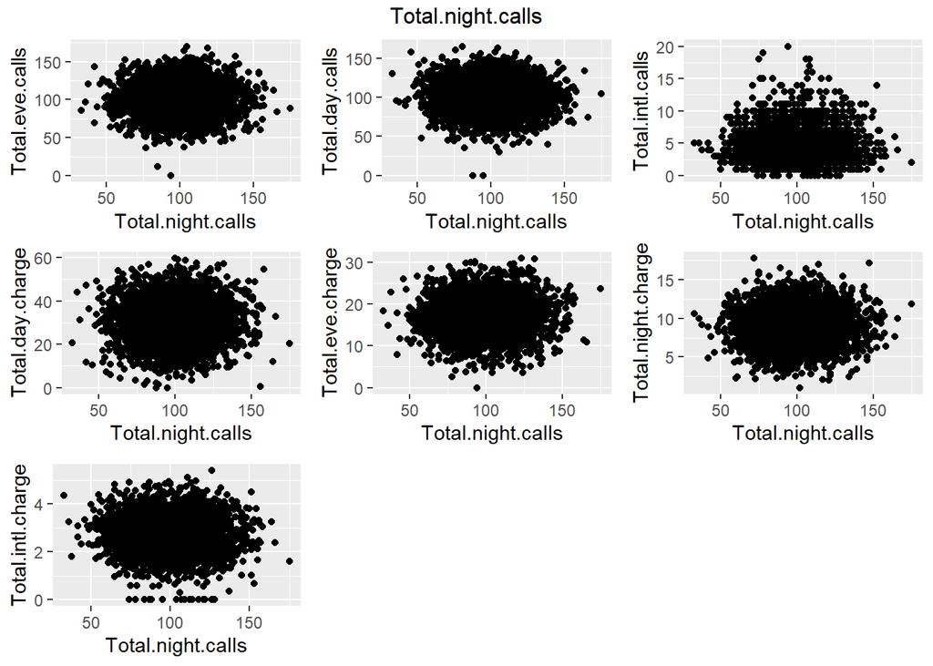

```r
grid.arrange(ggplot(churn_data)+ geom_point(aes(x=Total.night.calls, y = Total.eve.calls)),
             ggplot(churn_data)+ geom_point(aes(x=Total.night.calls, y = Total.day.calls)),
             ggplot(churn_data)+ geom_point(aes(x=Total.night.calls, y = Total.intl.calls)),
             ggplot(churn_data)+ geom_point(aes(x=Total.night.calls, y = Total.day.charge)),
             ggplot(churn_data)+ geom_point(aes(x=Total.night.calls, y = Total.eve.charge)),
             ggplot(churn_data)+ geom_point(aes(x=Total.night.calls, y = Total.night.charge)),
             ggplot(churn_data)+ geom_point(aes(x=Total.night.calls, y = Total.intl.charge)),
             top='Total.night.calls',nrow=3,
             heights = c(2, 2, 2))
```

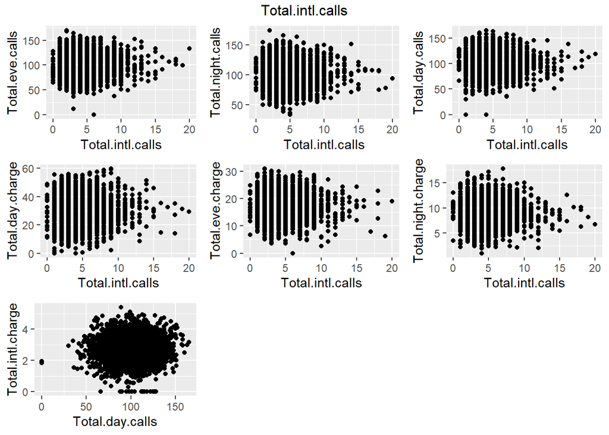

```r
grid.arrange(ggplot(churn_data)+ geom_point(aes(x=Total.intl.calls, y = Total.eve.calls)),
             ggplot(churn_data)+ geom_point(aes(x=Total.intl.calls, y = Total.night.calls)),
             ggplot(churn_data)+ geom_point(aes(x=Total.intl.calls, y = Total.day.calls)),
             ggplot(churn_data)+ geom_point(aes(x=Total.intl.calls, y = Total.day.charge)),
             ggplot(churn_data)+ geom_point(aes(x=Total.intl.calls, y = Total.eve.charge)),
             ggplot(churn_data)+ geom_point(aes(x=Total.intl.calls, y = Total.night.charge)),
             ggplot(churn_data)+ geom_point(aes(x=Total.day.calls, y = Total.intl.charge)),
             top='Total.intl.calls',nrow=3,
             heights = c(2, 2, 2))
```

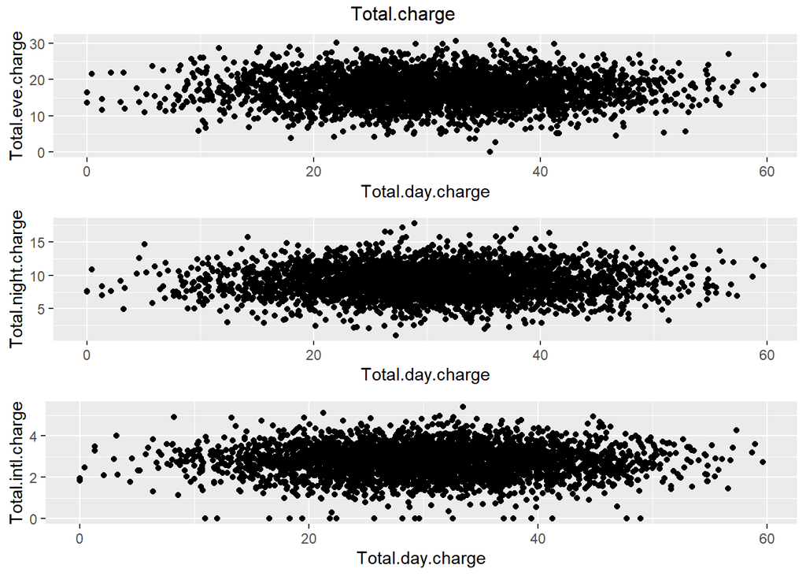

```r
grid.arrange(ggplot(churn_data)+ geom_point(aes(x=Total.day.charge, y = Total.eve.charge)),
             ggplot(churn_data)+ geom_point(aes(x=Total.day.charge, y = Total.night.charge)),
             ggplot(churn_data)+ geom_point(aes(x=Total.day.charge, y = Total.intl.charge)),
             top='Total.charge',nrow=3,
             heights = c(2, 2, 2))
```

## 4.2 Base on above plots, the meaningful plots are the relationship between charge and minutes

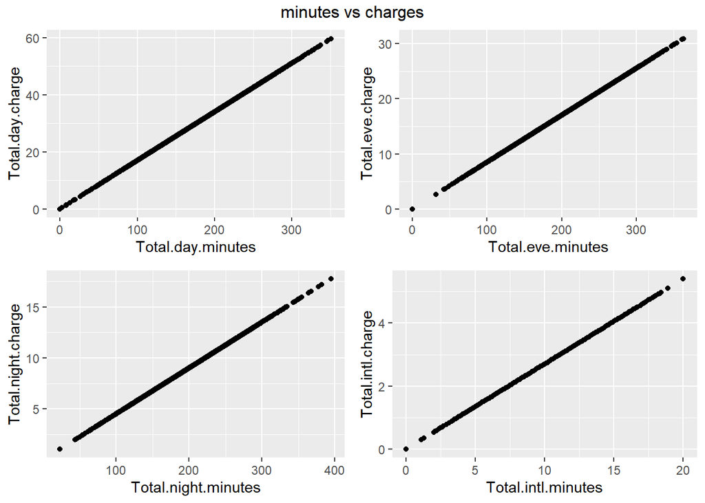

```r
grid.arrange(ggplot(churn_data)+ geom_point(aes(x=Total.day.minutes, y = Total.day.charge)),
             ggplot(churn_data)+ geom_point(aes(x=Total.eve.minutes, y = Total.eve.charge)),
             ggplot(churn_data)+ geom_point(aes(x=Total.night.minutes, y = Total.night.charge)),
             ggplot(churn_data)+ geom_point(aes(x=Total.intl.minutes, y = Total.intl.charge)),
             top='minutes vs charges',nrow=2,
             heights = c(2, 2))
```

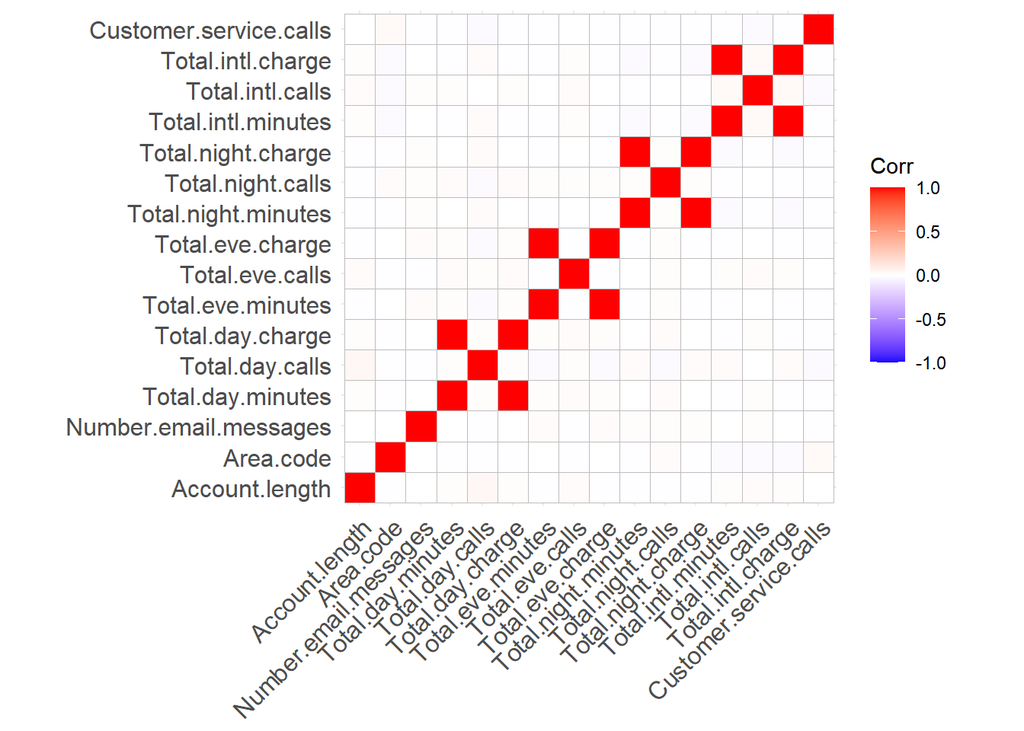

```r
library(ggcorrplot)
cor1 = cor(churn_data %>%select_if(is.numeric))
ggcorrplot(cor1)
```

```r
round(cor1,2)
```

```
##                        Account.length Area.code Number.email.messages
## Account.length                   1.00     -0.01                  0.00
## Area.code                       -0.01      1.00                  0.00
## Number.email.messages            0.00      0.00                  1.00
## Total.day.minutes                0.01     -0.01                  0.00
## Total.day.calls                  0.04     -0.01                 -0.01
## Total.day.charge                 0.01     -0.01                  0.00
## Total.eve.minutes               -0.01      0.00                  0.02
## Total.eve.calls                  0.02     -0.01                 -0.01
## Total.eve.charge                -0.01      0.00                  0.02
## Total.night.minutes             -0.01     -0.01                  0.01
## Total.night.calls               -0.01      0.02                  0.01
## Total.night.charge              -0.01     -0.01                  0.01
## Total.intl.minutes               0.01     -0.02                  0.00
## Total.intl.calls                 0.02     -0.02                  0.01
## Total.intl.charge                0.01     -0.02                  0.00
## Customer.service.calls           0.00      0.03                 -0.01
##                        Total.day.minutes Total.day.calls Total.day.charge
## Account.length                      0.01            0.04             0.01
## Area.code                          -0.01           -0.01            -0.01
## Number.email.messages               0.00           -0.01             0.00
## Total.day.minutes                   1.00            0.01             1.00
## Total.day.calls                     0.01            1.00             0.01
## Total.day.charge                    1.00            0.01             1.00
## Total.eve.minutes                   0.01           -0.02             0.01
## Total.eve.calls                     0.02            0.01             0.02
## Total.eve.charge                    0.01           -0.02             0.01
## Total.night.minutes                 0.00            0.02             0.00
## Total.night.calls                   0.02           -0.02             0.02
## Total.night.charge                  0.00            0.02             0.00
## Total.intl.minutes                 -0.01            0.02            -0.01
## Total.intl.calls                    0.01            0.00             0.01
## Total.intl.charge                  -0.01            0.02            -0.01
## Customer.service.calls             -0.01           -0.02            -0.01
##                        Total.eve.minutes Total.eve.calls Total.eve.charge
## Account.length                     -0.01            0.02            -0.01
## Area.code                           0.00           -0.01             0.00
## Number.email.messages               0.02           -0.01             0.02
## Total.day.minutes                   0.01            0.02             0.01
## Total.day.calls                    -0.02            0.01            -0.02
```

[output cut: 47 more lines]

```
## Area.code                                0.03
## Number.email.messages                   -0.01
## Total.day.minutes                       -0.01
## Total.day.calls                         -0.02
## Total.day.charge                        -0.01
## Total.eve.minutes                       -0.01
## Total.eve.calls                          0.00
## Total.eve.charge                        -0.01
## Total.night.minutes                     -0.01
## Total.night.calls                       -0.01
## Total.night.charge                      -0.01
## Total.intl.minutes                      -0.01
## Total.intl.calls                        -0.02
## Total.intl.charge                       -0.01
## Customer.service.calls                   1.00
```

## 4.3 Category/Category

```r
fcs
```

```
## [1] "State"              "International.plan" "Voice.mail.plan"
## [4] "Churn"
```

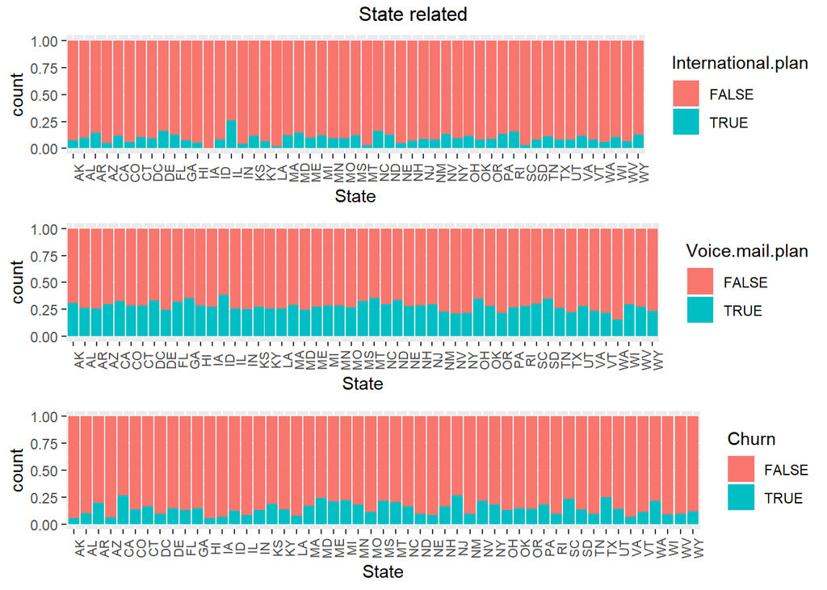

```r
grid.arrange(ggplot(churn_data) + geom_bar(aes(fill= International.plan, x = State),position="fill")+theme(axis.text.x = element_text(angle = 90, size = 8)),
             ggplot(churn_data) + geom_bar(aes(fill = Voice.mail.plan, x = State),position="fill")+theme(axis.text.x = element_text(angle = 90, size = 8)),
             ggplot(churn_data) + geom_bar(aes(fill = Churn, x = State),position="fill")+theme(axis.text.x = element_text(angle = 90, size = 8)),
             top='State related')
```

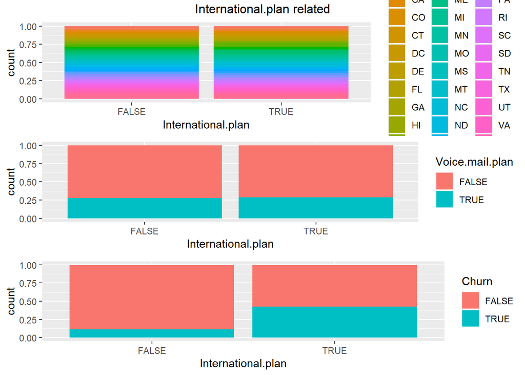

```r
grid.arrange(ggplot(churn_data) + geom_bar(aes(fill= State, x = International.plan),position="fill"),
             ggplot(churn_data) + geom_bar(aes(fill = Voice.mail.plan, x = International.plan),position="fill"),
             ggplot(churn_data) + geom_bar(aes(fill = Churn, x = International.plan),position="fill"),
             top='International.plan related')
```

```r
chisq.test(table(churn_data$International.plan,churn_data$Churn))
```

```
##
##  Pearson's Chi-squared test with Yates' continuity correction
##
## data:  table(churn_data$International.plan, churn_data$Churn)
## X-squared = 222.57, df = 1, p-value < 2.2e-16
```

```r
chisq.test(table(churn_data$International.plan,churn_data$Voice.mail.plan))
```

```
##
##  Pearson's Chi-squared test with Yates' continuity correction
##
## data:  table(churn_data$International.plan, churn_data$Voice.mail.plan)
## X-squared = 0.079139, df = 1, p-value = 0.7785
```

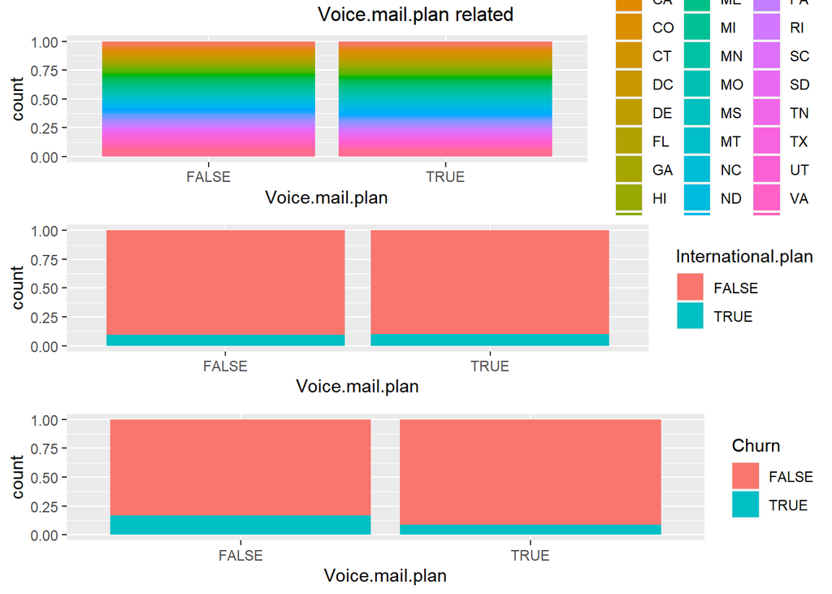

```r
grid.arrange(ggplot(churn_data) + geom_bar(aes(fill= State, x = Voice.mail.plan),position="fill"),
             ggplot(churn_data) + geom_bar(aes(fill = International.plan, x = Voice.mail.plan),position="fill"),
             ggplot(churn_data) + geom_bar(aes(fill = Churn, x = Voice.mail.plan),position="fill"),
             top='Voice.mail.plan related')
```

```r
chisq.test(table(churn_data$Voice.mail.plan,churn_data$Churn))
```

```
##
##  Pearson's Chi-squared test with Yates' continuity correction
##
## data:  table(churn_data$Voice.mail.plan, churn_data$Churn)
## X-squared = 34.132, df = 1, p-value = 5.151e-09
```

```r
chisq.test(table(churn_data$Voice.mail.plan,churn_data$International.plan))
```

```
##
##  Pearson's Chi-squared test with Yates' continuity correction
##
## data:  table(churn_data$Voice.mail.plan, churn_data$International.plan)
## X-squared = 0.079139, df = 1, p-value = 0.7785
```

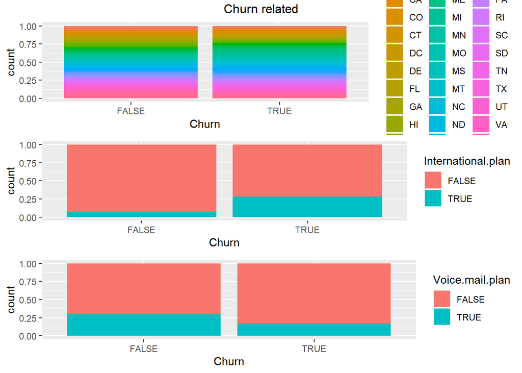

```r
grid.arrange(ggplot(churn_data) + geom_bar(aes(fill= State, x = Churn),position="fill"),
             ggplot(churn_data) + geom_bar(aes(fill = International.plan, x = Churn),position="fill"),
             ggplot(churn_data) + geom_bar(aes(fill = Voice.mail.plan, x = Churn),position="fill"),
             top='Churn related')
```

```r
chisq.test(table(churn_data$Churn,churn_data$International.plan))
```

```
##
##  Pearson's Chi-squared test with Yates' continuity correction
##
## data:  table(churn_data$Churn, churn_data$International.plan)
## X-squared = 222.57, df = 1, p-value < 2.2e-16
```

```r
chisq.test(table(churn_data$Churn,churn_data$Voice.mail.plan))
```

```
##
##  Pearson's Chi-squared test with Yates' continuity correction
##
## data:  table(churn_data$Churn, churn_data$Voice.mail.plan)
## X-squared = 34.132, df = 1, p-value = 5.151e-09
```

```r
chisq.test(table(churn_data$Churn,churn_data$State))
```

```
##
##  Pearson's Chi-squared test
##
## data:  table(churn_data$Churn, churn_data$State)
## X-squared = 83.044, df = 50, p-value = 0.002296
```

## 4.4 Category/Measure

```r
nms
```

```
##  [1] "Account.length"         "Area.code"              "Number.email.messages"
##  [4] "Total.day.minutes"      "Total.day.calls"        "Total.day.charge"
##  [7] "Total.eve.minutes"      "Total.eve.calls"        "Total.eve.charge"
## [10] "Total.night.minutes"    "Total.night.calls"      "Total.night.charge"
## [13] "Total.intl.minutes"     "Total.intl.calls"       "Total.intl.charge"
## [16] "Customer.service.calls"
```

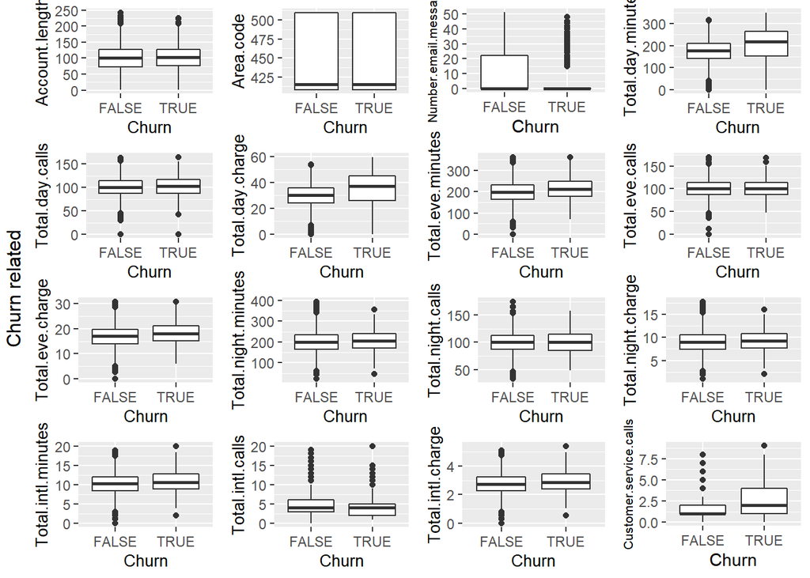

```r
size_a = 10
grid.arrange(ggplot(churn_data,aes(x =Churn,y=Account.length)) + geom_boxplot()+theme(axis.title=element_text(size=size_a)),
             ggplot(churn_data,aes(x =Churn,y=Area.code)) + geom_boxplot()+theme(axis.title=element_text(size=size_a)),
             ggplot(churn_data,aes(x =Churn,y=Number.email.messages)) + geom_boxplot()+theme(axis.title.y=element_text(size=8)),
             ggplot(churn_data,aes(x =Churn,y=Total.day.minutes)) + geom_boxplot()+theme(axis.title=element_text(size=size_a)),
             ggplot(churn_data,aes(x =Churn,y=Total.day.calls)) + geom_boxplot()+theme(axis.title=element_text(size=size_a)),
             ggplot(churn_data,aes(x =Churn,y=Total.day.charge)) + geom_boxplot()+theme(axis.title=element_text(size=size_a)),
             ggplot(churn_data,aes(x =Churn,y=Total.eve.minutes)) + geom_boxplot()+theme(axis.title=element_text(size=size_a)),
             ggplot(churn_data,aes(x =Churn,y=Total.eve.calls)) + geom_boxplot()+theme(axis.title=element_text(size=size_a)),
             ggplot(churn_data,aes(x =Churn,y=Total.eve.charge)) + geom_boxplot()+theme(axis.title=element_text(size=size_a)),
             ggplot(churn_data,aes(x =Churn,y=Total.night.minutes)) + geom_boxplot()+theme(axis.title=element_text(size=size_a)),
             ggplot(churn_data,aes(x =Churn,y=Total.night.calls)) + geom_boxplot()+theme(axis.title=element_text(size=size_a)),
             ggplot(churn_data,aes(x =Churn,y=Total.night.charge)) + geom_boxplot()+theme(axis.title=element_text(size=size_a)),
             ggplot(churn_data,aes(x =Churn,y=Total.intl.minutes)) + geom_boxplot()+theme(axis.title=element_text(size=size_a)),
             ggplot(churn_data,aes(x =Churn,y=Total.intl.calls)) + geom_boxplot()+theme(axis.title=element_text(size=size_a)),
             ggplot(churn_data,aes(x =Churn,y=Total.intl.charge)) + geom_boxplot()+theme(axis.title=element_text(size=size_a)),
             ggplot(churn_data,aes(x =Churn,y=Customer.service.calls)) + geom_boxplot()+theme(axis.title.y=element_text(size=8)),
             left='Churn related')
```

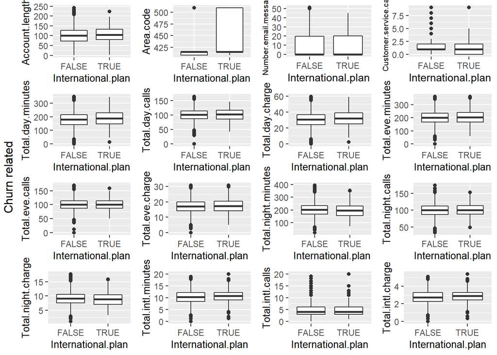

```r
grid.arrange(ggplot(churn_data,aes(x =International.plan,y=Account.length)) + geom_boxplot()+theme(axis.title=element_text(size=size_a)),
             ggplot(churn_data,aes(x =International.plan,y=Area.code)) + geom_boxplot()+theme(axis.title=element_text(size=size_a)),
             ggplot(churn_data,aes(x =International.plan,y=Number.email.messages)) + geom_boxplot()+theme(axis.title.y=element_text(size=8)),
              ggplot(churn_data,aes(x =International.plan,y=Customer.service.calls)) + geom_boxplot()+theme(axis.title.y=element_text(size=8)),
             ggplot(churn_data,aes(x =International.plan,y=Total.day.minutes)) + geom_boxplot()+theme(axis.title=element_text(size=size_a)),
             ggplot(churn_data,aes(x =International.plan,y=Total.day.calls)) + geom_boxplot()+theme(axis.title=element_text(size=size_a)),
             ggplot(churn_data,aes(x =International.plan,y=Total.day.charge)) + geom_boxplot()+theme(axis.title=element_text(size=size_a)),
             ggplot(churn_data,aes(x =International.plan,y=Total.eve.minutes)) + geom_boxplot()+theme(axis.title=element_text(size=size_a)),
             ggplot(churn_data,aes(x =International.plan,y=Total.eve.calls)) + geom_boxplot()+theme(axis.title=element_text(size=size_a)),
             ggplot(churn_data,aes(x =International.plan,y=Total.eve.charge)) + geom_boxplot()+theme(axis.title=element_text(size=size_a)),
             ggplot(churn_data,aes(x =International.plan,y=Total.night.minutes)) + geom_boxplot()+theme(axis.title=element_text(size=size_a)),
             ggplot(churn_data,aes(x =International.plan,y=Total.night.calls)) + geom_boxplot()+theme(axis.title=element_text(size=size_a)),
             ggplot(churn_data,aes(x =International.plan,y=Total.night.charge)) + geom_boxplot()+theme(axis.title=element_text(size=size_a)),
             ggplot(churn_data,aes(x =International.plan,y=Total.intl.minutes)) + geom_boxplot()+theme(axis.title=element_text(size=size_a)),
             ggplot(churn_data,aes(x =International.plan,y=Total.intl.calls)) + geom_boxplot()+theme(axis.title=element_text(size=size_a)),
             ggplot(churn_data,aes(x =International.plan,y=Total.intl.charge)) + geom_boxplot()+theme(axis.title=element_text(size=size_a)),

             left='Churn related')
```

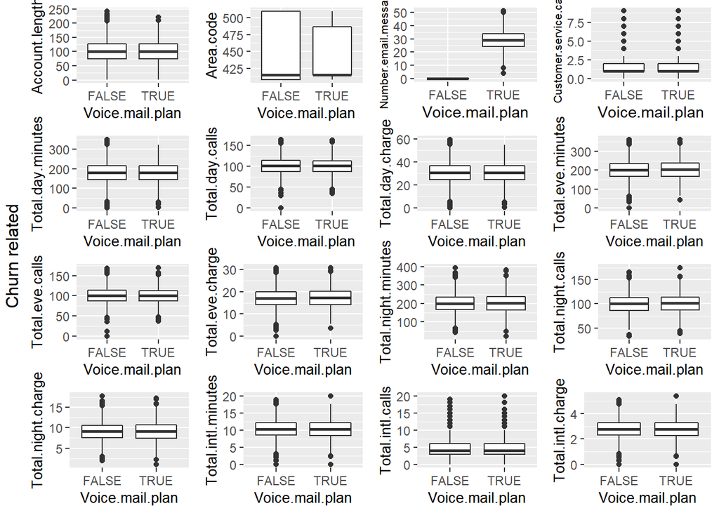

```r
grid.arrange(ggplot(churn_data,aes(x =Voice.mail.plan,y=Account.length)) + geom_boxplot()+theme(axis.title=element_text(size=size_a)),
             ggplot(churn_data,aes(x =Voice.mail.plan,y=Area.code)) + geom_boxplot()+theme(axis.title=element_text(size=size_a)),
             ggplot(churn_data,aes(x =Voice.mail.plan,y=Number.email.messages)) + geom_boxplot()+theme(axis.title.y=element_text(size=8)),ggplot(churn_data,aes(x =Voice.mail.plan,y=Customer.service.calls)) + geom_boxplot()+theme(axis.title.y=element_text(size=8)),
             ggplot(churn_data,aes(x =Voice.mail.plan,y=Total.day.minutes)) + geom_boxplot()+theme(axis.title=element_text(size=size_a)),
             ggplot(churn_data,aes(x =Voice.mail.plan,y=Total.day.calls)) + geom_boxplot()+theme(axis.title=element_text(size=size_a)),
             ggplot(churn_data,aes(x =Voice.mail.plan,y=Total.day.charge)) + geom_boxplot()+theme(axis.title=element_text(size=size_a)),
             ggplot(churn_data,aes(x =Voice.mail.plan,y=Total.eve.minutes)) + geom_boxplot()+theme(axis.title=element_text(size=size_a)),
             ggplot(churn_data,aes(x =Voice.mail.plan,y=Total.eve.calls)) + geom_boxplot()+theme(axis.title=element_text(size=size_a)),
             ggplot(churn_data,aes(x =Voice.mail.plan,y=Total.eve.charge)) + geom_boxplot()+theme(axis.title=element_text(size=size_a)),
             ggplot(churn_data,aes(x =Voice.mail.plan,y=Total.night.minutes)) + geom_boxplot()+theme(axis.title=element_text(size=size_a)),
             ggplot(churn_data,aes(x =Voice.mail.plan,y=Total.night.calls)) + geom_boxplot()+theme(axis.title=element_text(size=size_a)),
             ggplot(churn_data,aes(x =Voice.mail.plan,y=Total.night.charge)) + geom_boxplot()+theme(axis.title=element_text(size=size_a)),
             ggplot(churn_data,aes(x =Voice.mail.plan,y=Total.intl.minutes)) + geom_boxplot()+theme(axis.title=element_text(size=size_a)),
             ggplot(churn_data,aes(x =Voice.mail.plan,y=Total.intl.calls)) + geom_boxplot()+theme(axis.title=element_text(size=size_a)),
             ggplot(churn_data,aes(x =Voice.mail.plan,y=Total.intl.charge)) + geom_boxplot()+theme(axis.title=element_text(size=size_a)),
             left='Churn related')
```

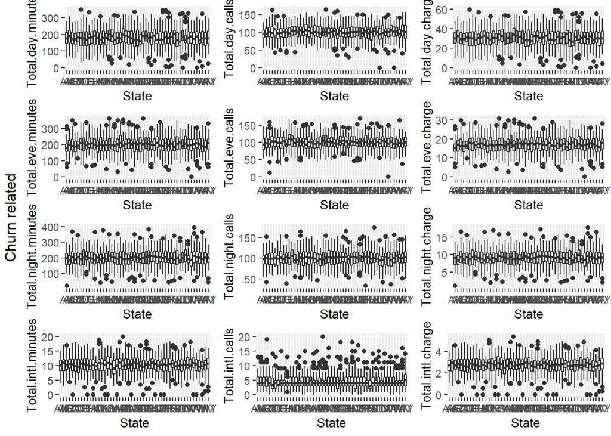

```r
grid.arrange(
             ggplot(churn_data,aes(x =State,y=Total.day.minutes)) + geom_boxplot()+theme(axis.title=element_text(size=size_a)),
             ggplot(churn_data,aes(x =State,y=Total.day.calls)) + geom_boxplot()+theme(axis.title=element_text(size=size_a)),
             ggplot(churn_data,aes(x =State,y=Total.day.charge)) + geom_boxplot()+theme(axis.title=element_text(size=size_a)),
             ggplot(churn_data,aes(x =State,y=Total.eve.minutes)) + geom_boxplot()+theme(axis.title=element_text(size=size_a)),
             ggplot(churn_data,aes(x =State,y=Total.eve.calls)) + geom_boxplot()+theme(axis.title=element_text(size=size_a)),
             ggplot(churn_data,aes(x =State,y=Total.eve.charge)) + geom_boxplot()+theme(axis.title=element_text(size=size_a)),
             ggplot(churn_data,aes(x =State,y=Total.night.minutes)) + geom_boxplot()+theme(axis.title=element_text(size=size_a)),
             ggplot(churn_data,aes(x =State,y=Total.night.calls)) + geom_boxplot()+theme(axis.title=element_text(size=size_a)),
             ggplot(churn_data,aes(x =State,y=Total.night.charge)) + geom_boxplot()+theme(axis.title=element_text(size=size_a)),
             ggplot(churn_data,aes(x =State,y=Total.intl.minutes)) + geom_boxplot()+theme(axis.title=element_text(size=size_a)),
             ggplot(churn_data,aes(x =State,y=Total.intl.calls)) + geom_boxplot()+theme(axis.title=element_text(size=size_a)),
             ggplot(churn_data,aes(x =State,y=Total.intl.charge)) + geom_boxplot()+theme(axis.title=element_text(size=size_a)),

             left='Churn related')
```

```r
names <- colnames(churn_data)
nm_index = c(2,3,6:19)
fc_index = c(1,4,5,20)
# for (j in fc_index) {
#   for (i in nm_index) {
#     t <- churn_data%>%group_by(churn_data[[j]])%>%summarise(Mean=mean(churn_data[[i]]),Median=median(churn_data[[i]]),SD=sd(churn_data[[i]]))
#     print(colnames(churn_data[j]))
#     print(colnames(churn_data[i]))
#     print(t)
#   }
# }
```

```r
churn_data%>%group_by(Churn)%>%summarise(Mean=mean(Number.email.messages),Median=median(Number.email.messages),SD=sd(Number.email.messages))
```

| Churn | Mean | Median | SD |
| --- | --- | --- | --- |
| FALSE | 8.604561 | 0 | 13.91313 |
| TRUE | 5.115942 | 0 | 11.86014 |

```r
churn_data%>%group_by(Churn)%>%summarise(Mean=mean(Customer.service.calls),Median=median(Customer.service.calls),SD=sd(Customer.service.calls))
```

| Churn | Mean | Median | SD |
| --- | --- | --- | --- |
| FALSE | 1.449825 | 1 | 1.163883 |
| TRUE | 2.229814 | 2 | 1.853275 |

```r
churn_data%>%group_by(Churn)%>%summarise(Mean=mean(Total.day.minutes),Median=median(Total.day.minutes),SD=sd(Total.day.minutes))
```

| Churn | Mean | Median | SD |
| --- | --- | --- | --- |
| FALSE | 175.1758 | 177.2 | 50.18166 |
| TRUE | 206.9141 | 217.6 | 68.99779 |

```r
churn_data%>%group_by(Churn)%>%summarise(Mean=mean(Total.day.calls),Median=median(Total.day.calls),SD=sd(Total.day.calls))
```

| Churn | Mean | Median | SD |
| --- | --- | --- | --- |
| FALSE | 100.2832 | 100 | 19.80116 |
| TRUE | 101.3354 | 103 | 21.58231 |

```r
churn_data%>%group_by(Churn)%>%summarise(Mean=mean(Total.day.charge),Median=median(Total.day.charge),SD=sd(Total.day.charge))
```

| Churn | Mean | Median | SD |
| --- | --- | --- | --- |
| FALSE | 29.78042 | 30.12 | 8.530836 |
| TRUE | 35.17592 | 36.99 | 11.729710 |

```r
churn_data%>%group_by(Churn)%>%summarise(Mean=mean(Total.eve.minutes),Median=median(Total.intl.calls),SD=sd(Total.eve.minutes))
```

| Churn | Mean | Median | SD |
| --- | --- | --- | --- |
| FALSE | 199.0433 | 4 | 50.29217 |
| TRUE | 212.4101 | 4 | 51.72891 |

```r
churn_data%>%group_by(Churn)%>%summarise(Mean=mean(Total.eve.calls),Median=median(Total.eve.calls),SD=sd(Total.eve.calls))
```

| Churn | Mean | Median | SD |
| --- | --- | --- | --- |
| FALSE | 100.0386 | 100 | 19.95841 |
| TRUE | 100.5611 | 101 | 19.72471 |

```r
churn_data%>%group_by(Churn)%>%summarise(Mean=mean(Total.eve.charge),Median=median(Total.eve.charge),SD=sd(Total.eve.charge))
```

| Churn | Mean | Median | SD |
| --- | --- | --- | --- |
| FALSE | 16.91891 | 16.97 | 4.274863 |
| TRUE | 18.05497 | 17.96 | 4.396762 |

```r
churn_data%>%group_by(Churn)%>%summarise(Mean=mean(Total.night.minutes),Median=median(Total.night.minutes),SD=sd(Total.night.minutes))
```

| Churn | Mean | Median | SD |
| --- | --- | --- | --- |
| FALSE | 200.1332 | 200.25 | 51.10503 |
| TRUE | 205.2317 | 204.80 | 47.13282 |

```r
churn_data%>%group_by(Churn)%>%summarise(Mean=mean(Total.night.calls),Median=median(Total.intl.calls),SD=sd(Total.night.calls))
```

| Churn | Mean | Median | SD |
| --- | --- | --- | --- |
| FALSE | 100.0582 | 4 | 19.50625 |
| TRUE | 100.3996 | 4 | 19.95066 |

```r
churn_data%>%group_by(Churn)%>%summarise(Mean=mean(Total.night.charge),Median=median(Total.night.charge),SD=sd(Total.night.charge))
```

| Churn | Mean | Median | SD |
| --- | --- | --- | --- |
| FALSE | 9.006074 | 9.01 | 2.299768 |
| TRUE | 9.235528 | 9.22 | 2.121081 |

```r
churn_data%>%group_by(Churn)%>%summarise(Mean=mean(Total.intl.minutes),Median=median(Total.intl.minutes),SD=sd(Total.intl.minutes))
```

| Churn | Mean | Median | SD |
| --- | --- | --- | --- |
| FALSE | 10.15888 | 10.2 | 2.784489 |
| TRUE | 10.70000 | 10.6 | 2.793190 |

```r
churn_data%>%group_by(Churn)%>%summarise(Mean=mean(Total.intl.calls),Median=median(Total.intl.calls),SD=sd(Total.intl.calls))
```

| Churn | Mean | Median | SD |
| --- | --- | --- | --- |
| FALSE | 4.532983 | 4 | 2.441984 |
| TRUE | 4.163561 | 4 | 2.551575 |

```r
churn_data%>%group_by(Churn)%>%summarise(Mean=mean(Total.intl.charge),Median=median(Total.intl.charge),SD=sd(Total.intl.charge))
```

| Churn | Mean | Median | SD |
| --- | --- | --- | --- |
| FALSE | 2.743403 | 2.75 | 0.7517843 |
| TRUE | 2.889544 | 2.86 | 0.7541521 |

- More about churn

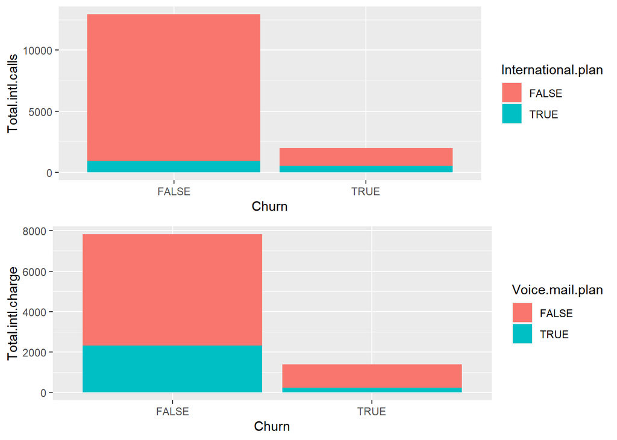

```r
grid.arrange(ggplot(churn_data, aes(x = Churn, y =Total.intl.calls, fill = International.plan)) + geom_bar(stat='identity'),
             ggplot(churn_data, aes(x = Churn, y =Total.intl.charge, fill = Voice.mail.plan)) + geom_bar(stat='identity'))
```

```r
for (i in nm_index) {
  tt <- t.test(churn_data[[i]]~churn_data$Churn,alternate="greater")
  cat(colnames(churn_data[i])," t-test with Churn, p value is ",tt$p.value," which p<0.05? ", (tt$p.value<0.05),"\n")
}
```

```
## Account.length  t-test with Churn, p value is  0.3364575  which p<0.05?  FALSE
## Area.code  t-test with Churn, p value is  0.7238496  which p<0.05?  FALSE
## Number.email.messages  t-test with Churn, p value is  8.764782e-09  which p<0.05?  TRUE
## Total.day.minutes  t-test with Churn, p value is  1.218968e-20  which p<0.05?  TRUE
## Total.day.calls  t-test with Churn, p value is  0.3165434  which p<0.05?  FALSE
## Total.day.charge  t-test with Churn, p value is  1.219876e-20  which p<0.05?  TRUE
## Total.eve.minutes  t-test with Churn, p value is  1.83908e-07  which p<0.05?  TRUE
## Total.eve.calls  t-test with Churn, p value is  0.5911801  which p<0.05?  FALSE
## Total.eve.charge  t-test with Churn, p value is  1.842608e-07  which p<0.05?  TRUE
## Total.night.minutes  t-test with Churn, p value is  0.03028049  which p<0.05?  TRUE
## Total.night.calls  t-test with Churn, p value is  0.7273389  which p<0.05?  FALSE
## Total.night.charge  t-test with Churn, p value is  0.03027154  which p<0.05?  TRUE
## Total.intl.minutes  t-test with Churn, p value is  9.065715e-05  which p<0.05?  TRUE
## Total.intl.calls  t-test with Churn, p value is  0.003185777  which p<0.05?  TRUE
## Total.intl.charge  t-test with Churn, p value is  9.025887e-05  which p<0.05?  TRUE
## Customer.service.calls  t-test with Churn, p value is  5.27004e-18  which p<0.05?  TRUE
```